# Projet

les individus les mieux représentés sur les axes que nous avons conservés

```r
# Qualité de la représentation des individus
sort(round(acp.wine$ind$cos2[,1]), decreasing=TRUE)[1:3]
```

```
##   S Michaud  S Renaudie S Trotignon
##           1           1           1
```

```r
sort(round(acp.wine$ind$cos2[,2]), decreasing=TRUE)[1:3]
```

```
## V Aub Silex   S Michaud  S Renaudie
##           1           0           0
```

```r
sort(round(acp.wine$ind$cos2[,3]), decreasing=TRUE)[1:3]
```

```
##   S Michaud  S Renaudie S Trotignon
##           0           0           0
```

- Les indidvidus les mieux représentés sur le premier axe sont Michaud, Renaudie et Trotignon
- Les indidvidus les mieux représentés sur le deuxième axe sont Aub Silex, Michaud et Renaudie
- Les indidvidus les mieux représentés sur le troisième axe sont Michaud, Renaudie et Trotignon

```r
# Contribution des individus aux axes
sort(round(acp.wine$ind$contrib[,1]),decreasing=TRUE)[1:3]
```

```
##     S Michaud V Font Brules    S Renaudie
##            16            16            15
```

```r
sort(round(acp.wine$ind$contrib[,2]),decreasing=TRUE)[1:3]
```

```
##      V Aub Silex    V Aub Marigny S Buisse Domaine
##               52               15               14
```

```r
sort(round(acp.wine$ind$contrib[,3]),decreasing=TRUE)[1:3]
```

```
##  V Font Brules  V Aub Marigny V Font Domaine
##             40             25             10
```

On en déduit que: -les vins qui contribuent le plus sur l’axe 1 sont Michaud, Font Brules et Renaudie. -les vins qui contribuent le plus sur l’axe 2 sont Aub Silex, Aub Marginy et Buisse Domaine. -les vins qui contribuent les plus sur l’axe 3 sont FOnt Brules, Aub Marginy et FOnt Domaine

la projection des individus sur le plan engendré par les deux premiers axes factoriels

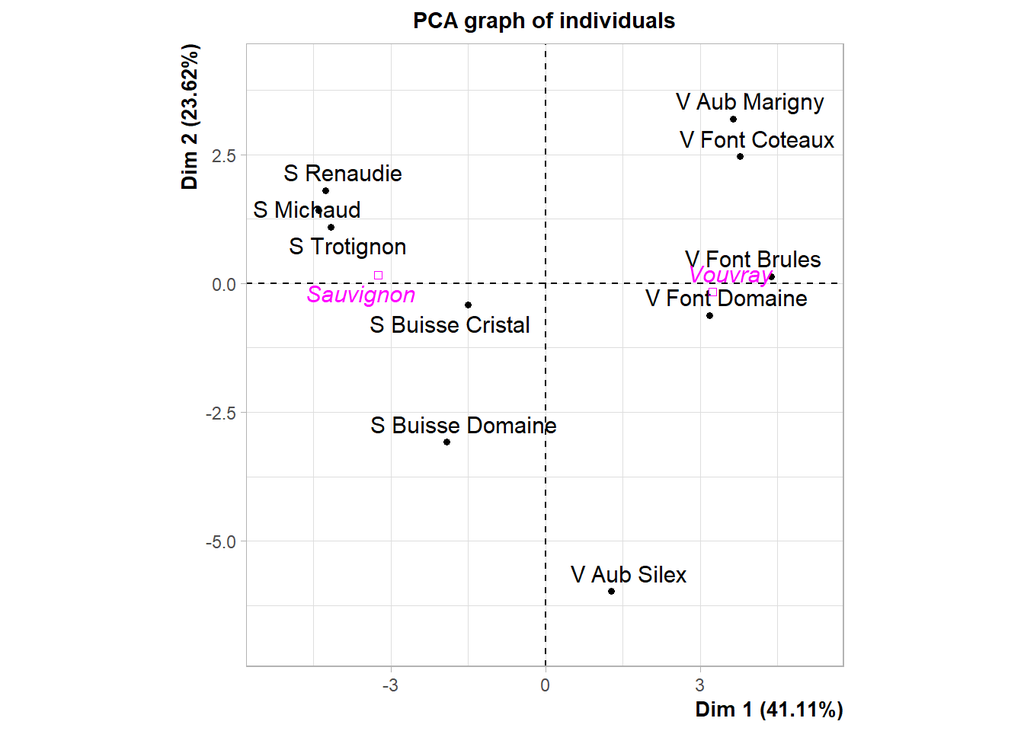

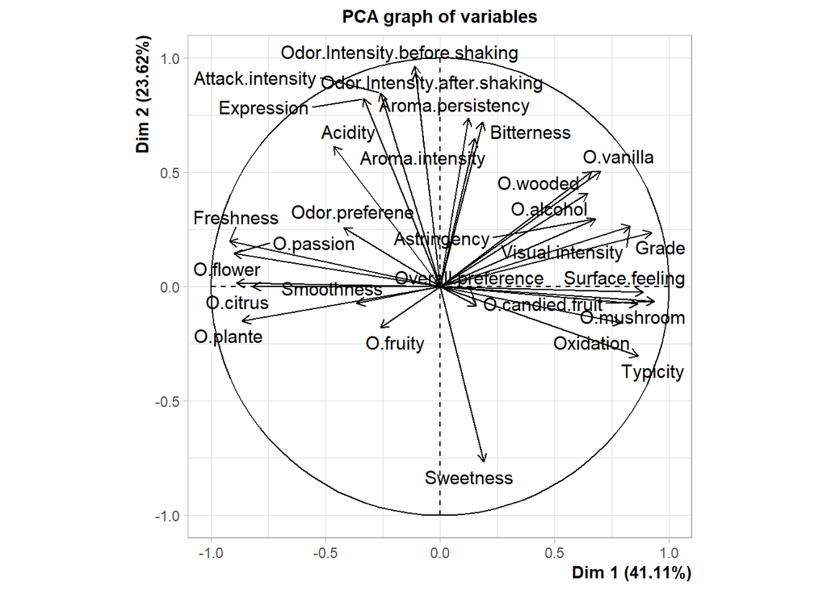

```r
# Graphiques sur les deux premiers plans factoriels
acp.wine<-PCA(donnee2, scale.unit=TRUE, graph=T, ncp=2,quali.sup=1)
```

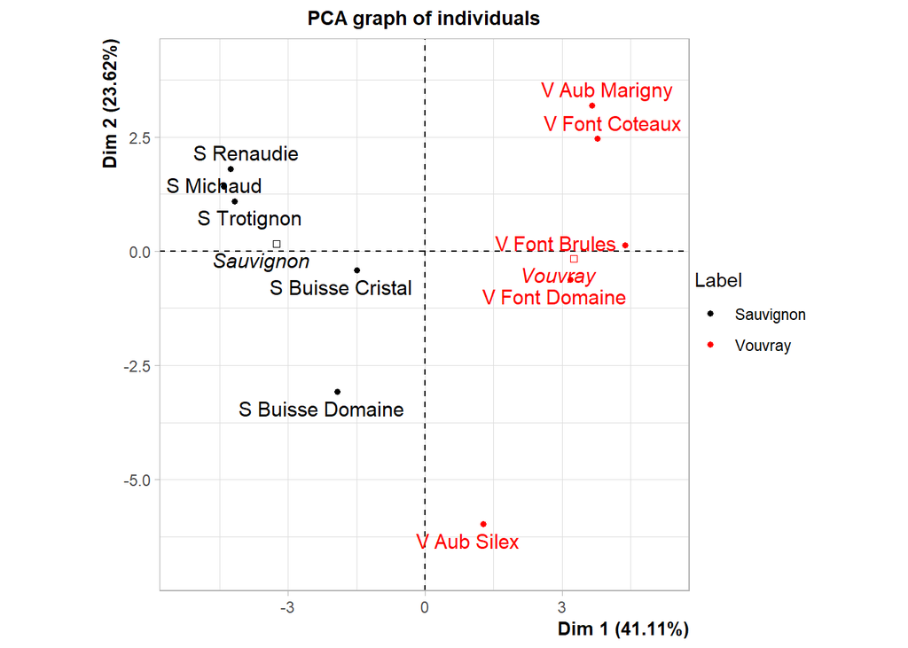

```r
# On colorie les individus suivant leur étiquette.
plot(acp.wine,habillage=1)
```

Qualité de la représentation des variables

```r
sort(acp.wine$var$cos2[,1],decreasing=TRUE)[1:3]
```

```
## O.candied.fruit           Grade       Freshness
##       0.8768974       0.8535524       0.8430466
```

```r
sort(acp.wine$var$cos2[,2],decreasing=TRUE)[1:3]
```

```
## Odor.Intensity.before.shaking  Odor.Intensity.after.shaking
##                     0.9300589                     0.8730484
##              Attack.intensity
##                     0.7158286
```

En concluant: - Les variables les mieux représentées sur le premier axe sont Odor.candied.fruit, Grade et Freshness - Les variables les mieux représentées sur le deuxième axe sont Odor.Intensity.before.shaking, Odor.Intensity.after.shaking et Attack.intensity

Les variables qui contribuent le plus:

```r
sort(acp.wine$var$contrib[,1],decreasing=TRUE)[1:3]
```

```
## O.candied.fruit           Grade       Freshness
##        7.355748        7.159920        7.071794
```

```r
sort(acp.wine$var$contrib[,2],decreasing=TRUE)[1:3]
```

```
## Odor.Intensity.before.shaking  Odor.Intensity.after.shaking
##                      13.57918                      12.74680
##              Attack.intensity
##                      10.45134
```

remarque: on a observé que les variables qui contribuent le plus sont toujours bien présentés sur les deux premiers axes.

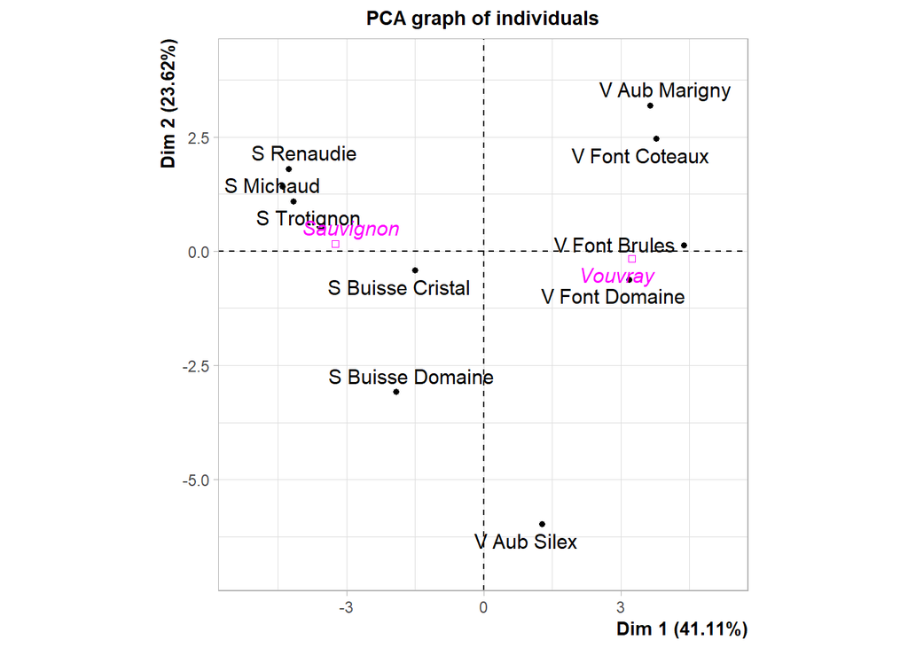

```r
## Selection of some individuals

#plot the 10 individuals that have the highest contribution sur le plan factoriel
plot(acp.wine,select="contrib 10")
```

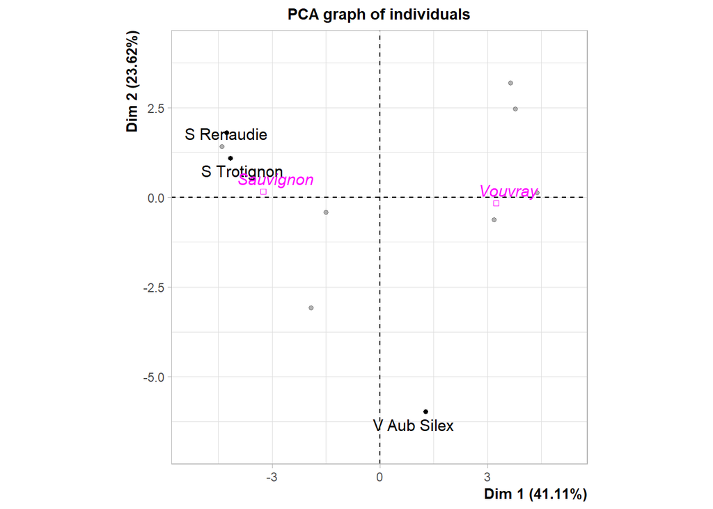

```r
#plot the individuals that have a cos2 greater than 0.7 sur le plan factoriel
plot(acp.wine,select="cos2 0.7")
```

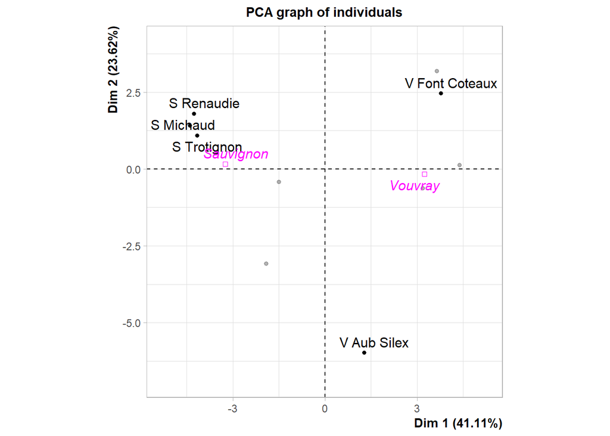

```r
#plot the 5 individuals that have the highest cos2 sur le plan factoriel
plot(acp.wine,select="cos2 5")
```

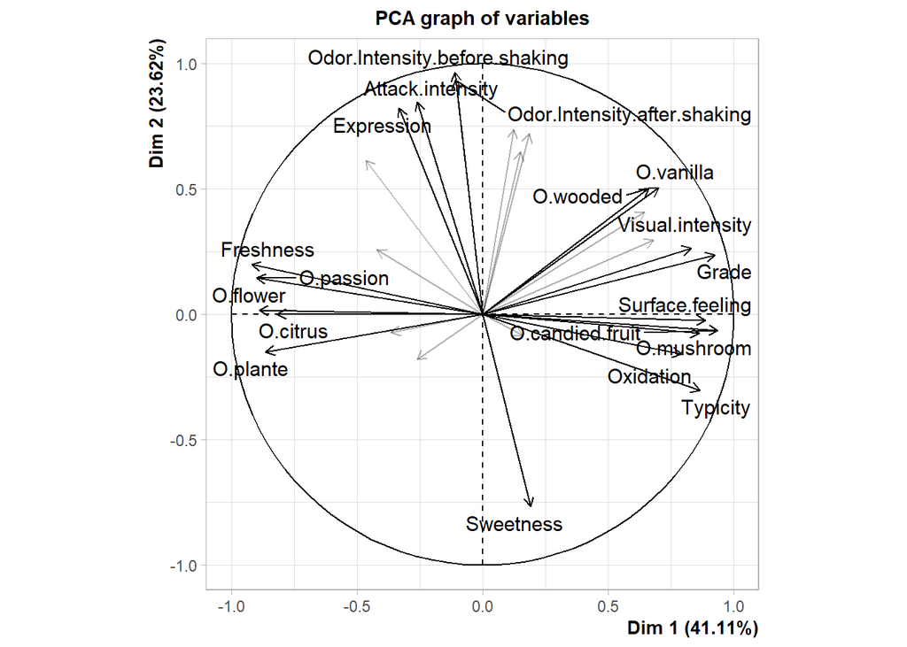

```r
#plot the variables that have a cos2 greater than 0.6 sur le plan factoriel
plot(acp.wine,choix="var",select="cos2 0.6")
```

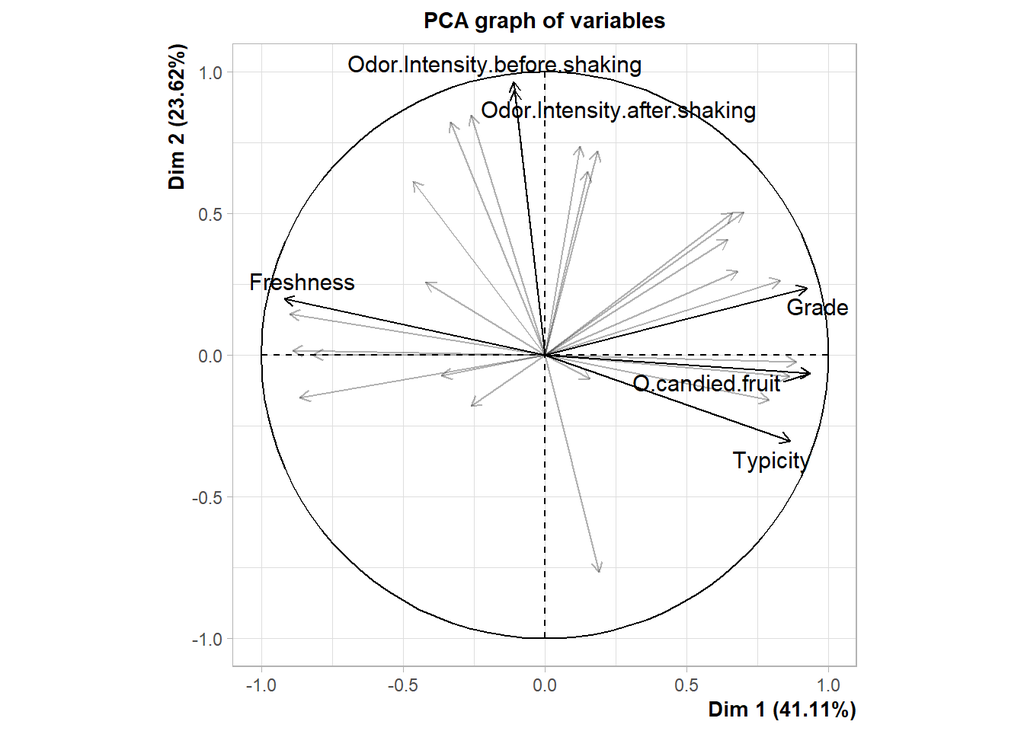

```r
#plot the 3 variables that have the highest contribution sur le plan factoriel
plot(acp.wine,choix="var",select="contrib 6")
```

**Les caractéristiques gustatives correspondent en fait à leurs caractéristiques physiques**

- Plus la douceur est élevée, moins l’attaque est intense;
- Plus la fraîcheur est élevée, plus la typicité est faible.
- L’intensité visuelle la plus élevée est la sensation de surface, la qualité et la typicité supérieures.
- Plus l’intensité de l’odeur est élevée avant l’agitation, plus l’intensité d’attaque et l’expression sont élevées.
- La vanille, les boisés, les fruits confits et les champignons sont toujours madr pour les mêmes étiquettes, tandis que la fleur, les agrumes, la passion et la plante sont faites pour une autre.